# Diagnóstico de Modelos

github.com/nacmarino/maR

## Recapitulando

- **Meta-Análise**: "é a análise estatística de uma ampla coleção de resultados de estudos com o propósito de integrar a evidência disponível". (*Glass, 1976*)
- Em uma meta-análise, é essencial calcularmos ou extrairmos uma métrica de tamanho de efeito e também a sua variância, para que o peso de cada estudo seja proporcional à sua precisão.
- Não existe o melhor modelo para a sua meta-análise, mas sim o modelo que descreve melhor seus objetivos e perguntas.
- Documente todas as decisões e escolhas que você fizer durante o processo de seleção de trabalhos, extração de dados, cálculo de effect size e escolha dos modelos.

## Rodar um modelo não é ter um modelo

- Existem certos pressupostos que você precisa verificar para saber se o que o modelo promete é de fato real.
  - Distribuição dos resíduos segue distribuição normal;
  - Variância dos resíduos é homogênea entre grupos ou ao longo de um gradiente (válido somente quando incluímos moderadores);
  - Os resultados não estão sendo tendenciados por observações aberrantes.
- Além disso, o modelo de meta-análise possui métricas específicas que devem ser verificadas para determinar:
  - Extensão da heterogeneidade entre observações;
  - Extensão da heterogeneidade dentro das observações;
  - Heterogeneidade total e heterogeneidade explicada pelo modelo;
  - Heterogeneidade explicada por cada *moderador*;
  - Diferença entre os níveis do mesmo *moderador*.
- O que vale para modelos de ANOVA, Regressão, e etc, valem e funcionam de forma semelhante aqui.

## Validação do Modelo

- A promessa do modelo é real ou furada?
- Vamos trabalhar com essa ideia usando um exemplo prático diretamente no R, com os dados que temos trabalhado no `metafor`.

```r
library(metafor)
dat <- dat.bcg
dat <- escalc(measure="RR", ai=tpos, bi=tneg, ci=cpos, di=cneg, data=dat.bcg)
model1 <- rma(yi = yi, vi = vi, data = dat)
```

## Diagnóstico do Modelo

- O output de um modelo de meta-análise: parte a parte.

```r
model1
```

```
##
## Random-Effects Model (k = 13; tau^2 estimator: REML)
##
## tau^2 (estimated amount of total heterogeneity): 0.3132 (SE = 0.1664)
## tau (square root of estimated tau^2 value):      0.5597
## I^2 (total heterogeneity / total variability):   92.22%
## H^2 (total variability / sampling variability):  12.86
##
## Test for Heterogeneity:
## Q(df = 12) = 152.2330, p-val < .0001
##
## Model Results:
##
## estimate       se     zval     pval    ci.lb    ci.ub
##  -0.7145   0.1798  -3.9744   <.0001  -1.0669  -0.3622      ***
##
## ---
## Signif. codes:  0 '***' 0.001 '**' 0.01 '*' 0.05 '.' 0.1 ' ' 1
```

## Diagnóstico do Modelo

### Estimativas do Modelo

- **Estimate**: é a estimativa do efeito que você está interessado.
- **SE**: é o valor do erro associado à estimativa do efeito (utilizado para os testes de significância e cálculo do intervalo de confiança).
- **zval**: valor do teste estatístico deste termo no modelo.
- **pval**: valor de *p* para o teste estatístico.
- **CI**: intervalo de confiança inferior (*ci.lb*) e superior (*ci.lb*) da estimativa do efeito.

| estimate | se | zval | pval | ci.lb | ci.ub |
| --- | --- | --- | --- | --- | --- |
| -0.715 | 0.18 | -3.974 | 0 | -1.067 | -0.362 |

## Diagnóstico do Modelo

### Variância dos Random-Effects

- **\(\tau^2\)**: variância entre estudos (between-study variance) e erro associado à esta estimativa (*se.tau2*).
- \(\tau^2\) é estimado por REML, por conta disso, possui um erro associado à ela.

| estimate | se | zval | pval | ci.lb | ci.ub | tau2 | se.tau2 |
| --- | --- | --- | --- | --- | --- | --- | --- |
| -0.715 | 0.18 | -3.974 | 0 | -1.067 | -0.362 | 0.313 | 0.166 |

## Diagnóstico do Modelo

### Variância dos Random-Effects

- Você pode verificar o ajuste de \(\tau^2\) com o log-likelihood usando a função `profile.rma.uni`: deve haver um pico no gráfico.

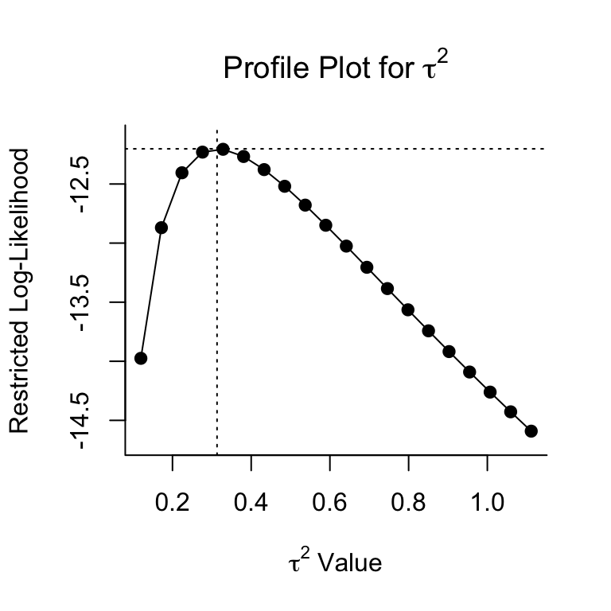

[output not shown]

## Diagnóstico do Modelo

### Testes de Heterogeneidade

```r
model1
```

```
##
## Random-Effects Model (k = 13; tau^2 estimator: REML)
##
## tau^2 (estimated amount of total heterogeneity): 0.3132 (SE = 0.1664)
## tau (square root of estimated tau^2 value):      0.5597
## I^2 (total heterogeneity / total variability):   92.22%
## H^2 (total variability / sampling variability):  12.86
##
## Test for Heterogeneity:
## Q(df = 12) = 152.2330, p-val < .0001
##
## Model Results:
##
## estimate       se     zval     pval    ci.lb    ci.ub
##  -0.7145   0.1798  -3.9744   <.0001  -1.0669  -0.3622      ***
##
## ---
## Signif. codes:  0 '***' 0.001 '**' 0.01 '*' 0.05 '.' 0.1 ' ' 1
```

## Diagnóstico do Modelo

### Testes de Heterogeneidade

- Uma estimativa de heterogeneidade na meta-análise é dada pela estatística Q, medida de forma similar à soma dos quadrados em uma ANOVA.
- A heterogeneidade total em um modelo de meta-análise é denotado por Q<sub>TOTAL</sub> ou Q<sub>T</sub>.
- Q<sub>T</sub> é a estatística de teste da hipótese nula (H<sub>0</sub>) de que todos os estudos formam uma amostra homogênea de uma população com efeito real \(\mu\) - isto é, *não existe heterogeneidade nos estudos*.
  - Aceita H<sub>0</sub>: não existe heterogeneidade;
  - Rejeita H<sub>0</sub>: existe evidência de heterogeneidade nos estudos.

## Diagnóstico do Modelo

### Testes de Heterogeneidade

- Q<sub>T</sub> é testado com base em uma distribuição do \(\chi^2\) com *k* - 1 graus de liberdade.
- Importante (mais sobre esses tópicos à seguir):
  - Q<sub>T</sub> representa a heterogeneidade oriunda da varibilidade de dentro (within-study variance) dos estudos em um fixed-effects model, e variabilidade oriunda de dentro (within-study variance) e entre (between-study variance) os estudos em um random-effects model.
  - Q<sub>T</sub> não deveria ser estatisticamente significativo em um random-effects model, pois toda a heterogeneidade adicional está sendo 'jogada' para a variabilidade entre estudos.

## Diagnóstico do Modelo

### Testes de Heterogeneidade

- No output que estamos trabalhando, o valor de Q não representa o valor de Q<sub>T</sub>, mas sim o quanto de que Q é causado por variância dentro dos estudos (Q<sub>E</sub>).
- A estatística Q não é comparável entre meta-análises e, por ser uma análise estatística, seu poder depende da quantidade de estudos incluídos.
- Uma alternativa complementar de medida de heterogeneidade é o **I<sup>2</sup>**, que **quantifica a porcentagem total da heterogeneidade que pode ser atribuído à variabilidade entre estudos**.

I<sup>2</sup>: *max* (100 x \(\frac{Q_T - (K - 1)}{Q_T}\), 0)  
(onde K é o número de estudos/graus de liberdade)

## Diagnóstico do Modelo

### Testes de Heterogeneidade

- Por fim, **H<sup>2</sup>** é uma outra métrica complementar de heterogeneidade que representa o **quanto cada estudo está contribuindo para a heterogeneidade do modelo**.

H<sup>2</sup>: \(\frac{Q_T}{K - 1}\)

| estimate | se | zval | pval | ci.lb | ci.ub | tau2 | se.tau2 | QE | QEp | I2 | H2 |
| --- | --- | --- | --- | --- | --- | --- | --- | --- | --- | --- | --- |
| -0.715 | 0.18 | -3.974 | 0 | -1.067 | -0.362 | 0.313 | 0.166 | 152.233 | 0 | 92.221 | 12.856 |

## Validação do Modelo

### Normalidade dos Resíduos

- Método gráfico *vs* método estatístico.

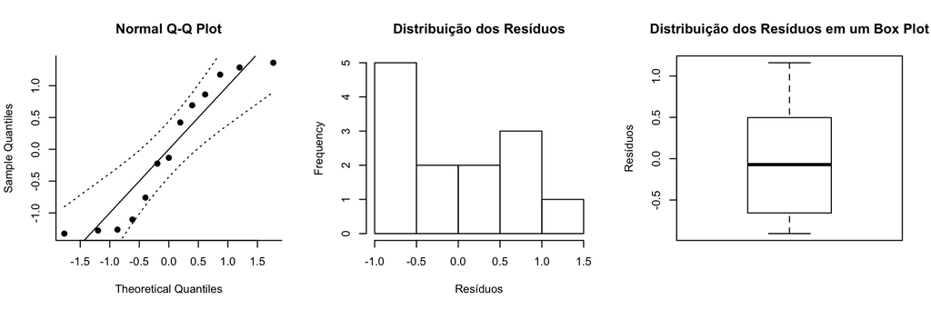

```r
qqnorm.rma.uni(model1)
hist(rstudent.rma.uni(model1)$resid, xlab = "Resíduos", main = "Distribuição dos Resíduos")
boxplot(resid(model1), ylab = "Resíduos", main = "Distribuição dos Resíduos em um Box Plot")
```

## Validação do Modelo

### Influência das Observações

- Diversos métodos disponíveis:
  - **Leave-One-Out**: exclui uma observação por vez, e determina como esta exclusão afeta a estimativa do parâmetro de interesse, bem como o ajuste do modelo.

```r
leave1out.rma.uni(model1)
```

| ids | estimate | se | zval | pval | ci.lb | ci.ub | Q | Qp | tau2 | I2 | H2 |
| --- | --- | --- | --- | --- | --- | --- | --- | --- | --- | --- | --- |
| 1 | -0.707 | 0.190 | -3.722 | 0 | -1.079 | -0.335 | 151.583 | 0 | 0.336 | 93.226 | 14.762 |
| 2 | -0.654 | 0.181 | -3.620 | 0 | -1.008 | -0.300 | 145.318 | 0 | 0.293 | 92.254 | 12.910 |
| 3 | -0.686 | 0.186 | -3.692 | 0 | -1.050 | -0.322 | 150.197 | 0 | 0.321 | 92.935 | 14.155 |
| 4 | -0.628 | 0.177 | -3.558 | 0 | -0.975 | -0.282 | 96.563 | 0 | 0.263 | 90.412 | 10.430 |
| 5 | -0.764 | 0.192 | -3.984 | 0 | -1.140 | -0.388 | 151.320 | 0 | 0.328 | 92.763 | 13.819 |
| 6 | -0.711 | 0.200 | -3.550 | 0 | -1.103 | -0.318 | 128.187 | 0 | 0.360 | 90.912 | 11.003 |
| 7 | -0.655 | 0.180 | -3.631 | 0 | -1.009 | -0.302 | 145.830 | 0 | 0.293 | 92.278 | 12.950 |
| 8 | -0.795 | 0.180 | -4.418 | 0 | -1.147 | -0.442 | 67.986 | 0 | 0.273 | 87.031 | 7.711 |
| 9 | -0.741 | 0.197 | -3.769 | 0 | -1.127 | -0.356 | 152.205 | 0 | 0.349 | 93.213 | 14.735 |
| 10 | -0.653 | 0.184 | -3.544 | 0 | -1.014 | -0.292 | 139.827 | 0 | 0.299 | 92.232 | 12.874 |
| 11 | -0.758 | 0.196 | -3.871 | 0 | -1.142 | -0.374 | 151.466 | 0 | 0.340 | 91.811 | 12.211 |
| 12 | -0.760 | 0.182 | -4.173 | 0 | -1.117 | -0.403 | 150.787 | 0 | 0.308 | 92.678 | 13.658 |
| 13 | -0.778 | 0.186 | -4.191 | 0 | -1.141 | -0.414 | 149.788 | 0 | 0.304 | 92.344 | 13.062 |

## Validação do Modelo

### Influência das Observações

- Diversos métodos disponíveis:
  - **\(\tau^2\)**: heterogeneidade entre estudos (between-study variance) quando o caso *i* é excluído.
  - **QE**: heterogeneidade residual quando caso *i* é excluído (veremos mais sobre QE a seguir).

```r
influence.rma.uni(model1)
```

| ids | rstudent | dffits | cook.d | cov.r | tau2.del | QE.del | hat | weight | dfbs |
| --- | --- | --- | --- | --- | --- | --- | --- | --- | --- |
| 1 | -0.22 | -0.04 | 0.00 | 1.12 | 0.34 | 151.58 | 0.05 | 5.06 | -0.04 |
| 2 | -1.29 | -0.34 | 0.11 | 1.01 | 0.29 | 145.32 | 0.06 | 6.36 | -0.35 |
| 3 | -0.75 | -0.16 | 0.03 | 1.07 | 0.32 | 150.20 | 0.04 | 4.44 | -0.16 |
| 4 | -1.45 | -0.52 | 0.23 | 0.97 | 0.26 | 96.56 | 0.10 | 9.70 | -0.51 |
| 5 | 0.85 | 0.27 | 0.08 | 1.14 | 0.33 | 151.32 | 0.09 | 8.87 | 0.27 |
| 6 | -0.12 | -0.02 | 0.00 | 1.24 | 0.36 | 128.19 | 0.10 | 10.10 | -0.02 |
| 7 | -1.30 | -0.34 | 0.11 | 1.01 | 0.29 | 145.83 | 0.06 | 6.03 | -0.34 |
| 8 | 1.45 | 0.48 | 0.20 | 1.00 | 0.27 | 67.99 | 0.10 | 10.19 | 0.47 |
| 9 | 0.41 | 0.14 | 0.02 | 1.20 | 0.35 | 152.21 | 0.09 | 8.74 | 0.14 |
| 10 | -1.13 | -0.35 | 0.12 | 1.05 | 0.30 | 139.83 | 0.08 | 8.37 | -0.35 |
| 11 | 0.67 | 0.23 | 0.06 | 1.19 | 0.34 | 151.47 | 0.10 | 9.93 | 0.23 |
| 12 | 1.29 | 0.25 | 0.06 | 1.03 | 0.31 | 150.79 | 0.04 | 3.82 | 0.25 |
| 13 | 1.19 | 0.35 | 0.12 | 1.07 | 0.30 | 149.79 | 0.08 | 8.40 | 0.35 |

## Validação do Modelo

### Influência das Observações

- Diversos métodos disponíveis:
  - **Externally Standardized Residuals**: descreve o quanto o desvio previsto pelo valor em *i* se afasta daquele que é previsto pelo modelo em sua ausência (resíduo muito grande indica que o caso não se ajusta ao modelo).

```r
influence.rma.uni(model1)
```

| ids | rstudent | dffits | cook.d | cov.r | tau2.del | QE.del | hat | weight | dfbs |
| --- | --- | --- | --- | --- | --- | --- | --- | --- | --- |
| 1 | -0.22 | -0.04 | 0.00 | 1.12 | 0.34 | 151.58 | 0.05 | 5.06 | -0.04 |
| 2 | -1.29 | -0.34 | 0.11 | 1.01 | 0.29 | 145.32 | 0.06 | 6.36 | -0.35 |
| 3 | -0.75 | -0.16 | 0.03 | 1.07 | 0.32 | 150.20 | 0.04 | 4.44 | -0.16 |
| 4 | -1.45 | -0.52 | 0.23 | 0.97 | 0.26 | 96.56 | 0.10 | 9.70 | -0.51 |
| 5 | 0.85 | 0.27 | 0.08 | 1.14 | 0.33 | 151.32 | 0.09 | 8.87 | 0.27 |
| 6 | -0.12 | -0.02 | 0.00 | 1.24 | 0.36 | 128.19 | 0.10 | 10.10 | -0.02 |
| 7 | -1.30 | -0.34 | 0.11 | 1.01 | 0.29 | 145.83 | 0.06 | 6.03 | -0.34 |
| 8 | 1.45 | 0.48 | 0.20 | 1.00 | 0.27 | 67.99 | 0.10 | 10.19 | 0.47 |
| 9 | 0.41 | 0.14 | 0.02 | 1.20 | 0.35 | 152.21 | 0.09 | 8.74 | 0.14 |
| 10 | -1.13 | -0.35 | 0.12 | 1.05 | 0.30 | 139.83 | 0.08 | 8.37 | -0.35 |
| 11 | 0.67 | 0.23 | 0.06 | 1.19 | 0.34 | 151.47 | 0.10 | 9.93 | 0.23 |
| 12 | 1.29 | 0.25 | 0.06 | 1.03 | 0.31 | 150.79 | 0.04 | 3.82 | 0.25 |
| 13 | 1.19 | 0.35 | 0.12 | 1.07 | 0.30 | 149.79 | 0.08 | 8.40 | 0.35 |

## Validação do Modelo

### Influência das Observações

- Diversos métodos disponíveis:
  - **dffits**: estima quantas unidades de desvio padrão o efeito predito pelo caso *i* muda após sua exclusão durante o ajuste do modelo (influência nos valores preditos).
  - **dfbetas**: estima quantas unidades de desvio padrão o coeficiente predito muda após a exclusão do caso *i* (influência nos slopes).

```r
influence.rma.uni(model1)
```

| ids | rstudent | dffits | cook.d | cov.r | tau2.del | QE.del | hat | weight | dfbs |
| --- | --- | --- | --- | --- | --- | --- | --- | --- | --- |
| 1 | -0.22 | -0.04 | 0.00 | 1.12 | 0.34 | 151.58 | 0.05 | 5.06 | -0.04 |
| 2 | -1.29 | -0.34 | 0.11 | 1.01 | 0.29 | 145.32 | 0.06 | 6.36 | -0.35 |
| 3 | -0.75 | -0.16 | 0.03 | 1.07 | 0.32 | 150.20 | 0.04 | 4.44 | -0.16 |
| 4 | -1.45 | -0.52 | 0.23 | 0.97 | 0.26 | 96.56 | 0.10 | 9.70 | -0.51 |
| 5 | 0.85 | 0.27 | 0.08 | 1.14 | 0.33 | 151.32 | 0.09 | 8.87 | 0.27 |
| 6 | -0.12 | -0.02 | 0.00 | 1.24 | 0.36 | 128.19 | 0.10 | 10.10 | -0.02 |
| 7 | -1.30 | -0.34 | 0.11 | 1.01 | 0.29 | 145.83 | 0.06 | 6.03 | -0.34 |
| 8 | 1.45 | 0.48 | 0.20 | 1.00 | 0.27 | 67.99 | 0.10 | 10.19 | 0.47 |
| 9 | 0.41 | 0.14 | 0.02 | 1.20 | 0.35 | 152.21 | 0.09 | 8.74 | 0.14 |
| 10 | -1.13 | -0.35 | 0.12 | 1.05 | 0.30 | 139.83 | 0.08 | 8.37 | -0.35 |
| 11 | 0.67 | 0.23 | 0.06 | 1.19 | 0.34 | 151.47 | 0.10 | 9.93 | 0.23 |
| 12 | 1.29 | 0.25 | 0.06 | 1.03 | 0.31 | 150.79 | 0.04 | 3.82 | 0.25 |
| 13 | 1.19 | 0.35 | 0.12 | 1.07 | 0.30 | 149.79 | 0.08 | 8.40 | 0.35 |

## Validação do Modelo

### Influência das Observações

- Diversos métodos disponíveis:
  - **Cook's Distance**: dissimilaridade no valores preditos pelos modelo quando a observação *i* é incluída *vs* quando ela é excluída.
  - **Hatvalues**: influência de cada caso *i* na estimativa do parâmetro de interesse.

```r
influence.rma.uni(model1)
```

| ids | rstudent | dffits | cook.d | cov.r | tau2.del | QE.del | hat | weight | dfbs |
| --- | --- | --- | --- | --- | --- | --- | --- | --- | --- |
| 1 | -0.22 | -0.04 | 0.00 | 1.12 | 0.34 | 151.58 | 0.05 | 5.06 | -0.04 |
| 2 | -1.29 | -0.34 | 0.11 | 1.01 | 0.29 | 145.32 | 0.06 | 6.36 | -0.35 |
| 3 | -0.75 | -0.16 | 0.03 | 1.07 | 0.32 | 150.20 | 0.04 | 4.44 | -0.16 |
| 4 | -1.45 | -0.52 | 0.23 | 0.97 | 0.26 | 96.56 | 0.10 | 9.70 | -0.51 |
| 5 | 0.85 | 0.27 | 0.08 | 1.14 | 0.33 | 151.32 | 0.09 | 8.87 | 0.27 |
| 6 | -0.12 | -0.02 | 0.00 | 1.24 | 0.36 | 128.19 | 0.10 | 10.10 | -0.02 |
| 7 | -1.30 | -0.34 | 0.11 | 1.01 | 0.29 | 145.83 | 0.06 | 6.03 | -0.34 |
| 8 | 1.45 | 0.48 | 0.20 | 1.00 | 0.27 | 67.99 | 0.10 | 10.19 | 0.47 |
| 9 | 0.41 | 0.14 | 0.02 | 1.20 | 0.35 | 152.21 | 0.09 | 8.74 | 0.14 |
| 10 | -1.13 | -0.35 | 0.12 | 1.05 | 0.30 | 139.83 | 0.08 | 8.37 | -0.35 |
| 11 | 0.67 | 0.23 | 0.06 | 1.19 | 0.34 | 151.47 | 0.10 | 9.93 | 0.23 |
| 12 | 1.29 | 0.25 | 0.06 | 1.03 | 0.31 | 150.79 | 0.04 | 3.82 | 0.25 |
| 13 | 1.19 | 0.35 | 0.12 | 1.07 | 0.30 | 149.79 | 0.08 | 8.40 | 0.35 |

## Validação do Modelo

### Influência das Observações

- Diversos métodos disponíveis:
  - **Weights**: peso de cada estudo no modelo (em %) (pouco relevante se você explicitamente determinou os pesos à serem usados).
  - **Covariance Ratio**: efeito do caso *i* na variânca do modelo (valores > 1 indicam que estudo aumenta variância do modelo).

```r
influence.rma.uni(model1)
```

| ids | rstudent | dffits | cook.d | cov.r | tau2.del | QE.del | hat | weight | dfbs |
| --- | --- | --- | --- | --- | --- | --- | --- | --- | --- |
| 1 | -0.22 | -0.04 | 0.00 | 1.12 | 0.34 | 151.58 | 0.05 | 5.06 | -0.04 |
| 2 | -1.29 | -0.34 | 0.11 | 1.01 | 0.29 | 145.32 | 0.06 | 6.36 | -0.35 |
| 3 | -0.75 | -0.16 | 0.03 | 1.07 | 0.32 | 150.20 | 0.04 | 4.44 | -0.16 |
| 4 | -1.45 | -0.52 | 0.23 | 0.97 | 0.26 | 96.56 | 0.10 | 9.70 | -0.51 |
| 5 | 0.85 | 0.27 | 0.08 | 1.14 | 0.33 | 151.32 | 0.09 | 8.87 | 0.27 |
| 6 | -0.12 | -0.02 | 0.00 | 1.24 | 0.36 | 128.19 | 0.10 | 10.10 | -0.02 |
| 7 | -1.30 | -0.34 | 0.11 | 1.01 | 0.29 | 145.83 | 0.06 | 6.03 | -0.34 |
| 8 | 1.45 | 0.48 | 0.20 | 1.00 | 0.27 | 67.99 | 0.10 | 10.19 | 0.47 |
| 9 | 0.41 | 0.14 | 0.02 | 1.20 | 0.35 | 152.21 | 0.09 | 8.74 | 0.14 |
| 10 | -1.13 | -0.35 | 0.12 | 1.05 | 0.30 | 139.83 | 0.08 | 8.37 | -0.35 |
| 11 | 0.67 | 0.23 | 0.06 | 1.19 | 0.34 | 151.47 | 0.10 | 9.93 | 0.23 |
| 12 | 1.29 | 0.25 | 0.06 | 1.03 | 0.31 | 150.79 | 0.04 | 3.82 | 0.25 |
| 13 | 1.19 | 0.35 | 0.12 | 1.07 | 0.30 | 149.79 | 0.08 | 8.40 | 0.35 |

## Validação do Modelo

### Influência das Observações

- Algumas diretrizes para considerar estudos influentes (*n* = graus de liberdade, *p* = número de coeficientes no modelo, *k* = número de estudos):
  - dffits > 3\(\sqrt\frac{p}{k-p}\)
  - dfbetas > 1
  - Cook's Distance corta mais que 50% da área da cauda de uma distribuição \(\chi^2\) com *n* graus de liberdade (existem outros valores para o cut-off: e.g. > 1, > \(\frac{4}{n}\), > \(\frac{4}{n - p - 1}\),…);
  - Hatvalues > 3\(\frac{p}{k}\)
- Estas diretrizes não são uma receita de bolo, e julgamento crítico dos valores deve ser exercitado.

## Diagnóstico do Modelo: Mixed-effects model

```r
(model2 <- rma(yi = yi, vi = vi, data = dat, mods = ~ ablat))
```

```
##
## Mixed-Effects Model (k = 13; tau^2 estimator: REML)
##
## tau^2 (estimated amount of residual heterogeneity):     0.0764 (SE = 0.0591)
## tau (square root of estimated tau^2 value):             0.2763
## I^2 (residual heterogeneity / unaccounted variability): 68.39%
## H^2 (unaccounted variability / sampling variability):   3.16
## R^2 (amount of heterogeneity accounted for):            75.62%
##
## Test for Residual Heterogeneity:
## QE(df = 11) = 30.7331, p-val = 0.0012
##
## Test of Moderators (coefficient(s) 2):
## QM(df = 1) = 16.3571, p-val < .0001
##
## Model Results:
##
##          estimate      se     zval    pval    ci.lb    ci.ub
## intrcpt    0.2515  0.2491   1.0095  0.3127  -0.2368   0.7397
## ablat     -0.0291  0.0072  -4.0444  <.0001  -0.0432  -0.0150  ***
##
## ---
## Signif. codes:  0 '***' 0.001 '**' 0.01 '*' 0.05 '.' 0.1 ' ' 1
```

## Mixed-effects model

### Estimativas do Modelo

- Note algumas diferenças no modelo de meta-regressão (mixed-effects model):
  - Você agora recebe um valor para o intercepto e slope do efeito da latitude;
  - Assim como em um regressão, você tem acesso à uma estimativa de R<sup>2</sup> (explicação do modelo);
  - O output agora te dá uma estimativa de QM (ou Q<sub>b</sub>, between-study variance) e QE (ou Q<sub>w</sub>, within-study variance);

| modelo | variavel | estimate | se | zval | pval | ci.lb | ci.ub |
| --- | --- | --- | --- | --- | --- | --- | --- |
| random-effects model | Estimativa | -0.71 | 0.18 | -3.97 | 0.00 | -1.07 | -0.36 |
| mixed-effects model | Intecepto | 0.25 | 0.25 | 1.01 | 0.31 | -0.24 | 0.74 |
| mixed-effects model | Latitude | -0.03 | 0.01 | -4.04 | 0.00 | -0.04 | -0.01 |

## Mixed-effects model

### Estimativas do Modelo

- Todas as estimativas de variabilidade não explicada caíram: \(\tau^2\), I<sup>2</sup> e Q<sup>2</sup>.

| tipo | tau2 | se.tau2 | QM | QMp | QE | QEp | I2 | H2 |
| --- | --- | --- | --- | --- | --- | --- | --- | --- |
| random-effects model | 0.31 | 0.17 | NA | NA | 152.23 | 0 | 92.22 | 12.86 |
| mixed-effects model | 0.08 | 0.06 | 16.36 | 0 | 30.73 | 0 | 68.39 | 3.16 |

## Mixed-effects model

### Testes de Heterogeneidade

- QE está testando a hipótese nula de que não existe heterogeneidade nos estudos - hipótese esta rejeitada no nosso exemplo.
- QM está testando a significância dos *termos no modelo*, e não do modelo todo.

```r
anova(model2) # compare com os resultados do output de model2
```

```
##
## Test of Moderators (coefficient(s) 2):
## QM(df = 1) = 16.3571, p-val < .0001
```

- A significância do modelo como um todo é dado por:

```r
anova(model2, btt = c(1,2)) # o teste fala quais coeficientes estão sendo testados
```

```
##
## Test of Moderators (coefficient(s) 1,2):
## QM(df = 2) = 54.6601, p-val < .0001
```

## Mixed-effects model: Moderadores Categóricos

```r
(model3 <- rma(yi = yi, vi = vi, data = dat, mods = ~ alloc))
```

```
##
## Mixed-Effects Model (k = 13; tau^2 estimator: REML)
##
## tau^2 (estimated amount of residual heterogeneity):     0.3615 (SE = 0.2111)
## tau (square root of estimated tau^2 value):             0.6013
## I^2 (residual heterogeneity / unaccounted variability): 88.77%
## H^2 (unaccounted variability / sampling variability):   8.91
## R^2 (amount of heterogeneity accounted for):            0.00%
##
## Test for Residual Heterogeneity:
## QE(df = 10) = 132.3676, p-val < .0001
##
## Test of Moderators (coefficient(s) 2,3):
## QM(df = 2) = 1.7675, p-val = 0.4132
##
## Model Results:
##
##                  estimate      se     zval    pval    ci.lb   ci.ub
## intrcpt           -0.5180  0.4412  -1.1740  0.2404  -1.3827  0.3468
## allocrandom       -0.4478  0.5158  -0.8682  0.3853  -1.4588  0.5632
## allocsystematic    0.0890  0.5600   0.1590  0.8737  -1.0086  1.1867
##
## ---
## Signif. codes:  0 '***' 0.001 '**' 0.01 '*' 0.05 '.' 0.1 ' ' 1
```

## Mixed-effects model: Moderadores Categóricos

- Com moderadores categóricos, QM está medindo a diferença estatístico entre o intercepto e cada um dos níveis do moderador par-a-par:
  - Quem é o intercepto?
  - O que representam estas diferenças então?

| variavel | estimate | se | zval | pval | ci.lb | ci.ub |
| --- | --- | --- | --- | --- | --- | --- |
| Intecepto | -0.518 | 0.441 | -1.174 | 0.240 | -1.383 | 0.347 |
| Allocation.Random | -0.448 | 0.516 | -0.868 | 0.385 | -1.459 | 0.563 |
| Allocation.Systematic | 0.089 | 0.560 | 0.159 | 0.874 | -1.009 | 1.187 |

## Mixed-effects model: Moderadores Categóricos

```r
anova(model3) # testando o efeito apenas de dois níveis do moderador
```

```
##
## Test of Moderators (coefficient(s) 2,3):
## QM(df = 2) = 1.7675, p-val = 0.4132
```

```r
anova(model3, btt = c(1,2,3)) # testando o efeito do moderador
```

```
##
## Test of Moderators (coefficient(s) 1,2,3):
## QM(df = 3) = 15.9842, p-val = 0.0011
```

## Mixed-effects model: Moderadores Categóricos

- Existe diferença entre os níveis do moderador, mas esta diferença é mascarada pelo padrão que o `metafor` assume.
- Uma alternativa é remover o intercepto do modelo: se cada nível do moderador é diferente de 0.
- Outra opção é reordernar os níveis do fator, determinando qual você quer que seja considerado com o 'intercepto' (especialmente útil se você tem hipóteses pré-definidas à serem testadas).
- Este problema é menor quando o moderador possui apenas 2 níveis.

## Mixed-effects model: Moderadores Categóricos

```r
model4 <- rma(yi = yi, vi = vi, data = dat, mods = ~ alloc - 1) # removendo o intercepto
```

| variavel | estimate | se | zval | pval | ci.lb | ci.ub |
| --- | --- | --- | --- | --- | --- | --- |
| Allocation.Alternate | -0.518 | 0.441 | -1.174 | 0.240 | -1.383 | 0.347 |
| Allocation.Random | -0.966 | 0.267 | -3.614 | 0.000 | -1.490 | -0.442 |
| Allocation.Systematic | -0.429 | 0.345 | -1.243 | 0.214 | -1.105 | 0.247 |

## Mixed-effects model: Moderadores Categóricos

- A função `anova` pode ser usada para fazer comparações par-a-par e até mesmo contrastes.

```r
anova(model4, L = c(1, -1, 0)) # "Allocation.Alternate" vs "Allocation.Random"
```

```
##
## Hypothesis:
## 1: allocalternate - allocrandom = 0
##
## Results:
##    estimate     se   zval   pval
## 1:   0.4478 0.5158 0.8682 0.3853
##
## Test of Hypothesis:
## QM(df = 1) = 0.7537, p-val = 0.3853
```

## Mixed-effects model: Moderadores Categóricos

- A função `anova` pode ser usada para fazer comparações par-a-par e até mesmo contrastes.

```r
anova(model4, L = c(1, -2, 1)) # "Allocation.Alternate" + "Allocation.Systematic" vs "Allocation.Random"
```

```
##
## Hypothesis:
## 1: allocalternate - 2*allocrandom + allocsystematic = 0
##
## Results:
##    estimate     se   zval   pval
## 1:   0.9847 0.7742 1.2719 0.2034
##
## Test of Hypothesis:
## QM(df = 1) = 1.6178, p-val = 0.2034
```

## Mixed-effects model

### Moderadores Categóricos e Contínuos

- Efeito principal dos dois moderadores.

```r
rma(yi = yi, vi = vi, data = dat, mods = ~ alloc + ablat)
```

| variavel | estimate | se | zval | pval | ci.lb | ci.ub |
| --- | --- | --- | --- | --- | --- | --- |
| Intercepto | 0.293 | 0.405 | 0.724 | 0.469 | -0.501 | 1.087 |
| Allocation.Random | -0.267 | 0.350 | -0.763 | 0.445 | -0.954 | 0.419 |
| Allocation.Systematic | 0.058 | 0.380 | 0.154 | 0.878 | -0.685 | 0.802 |
| Latitude | -0.027 | 0.009 | -2.965 | 0.003 | -0.045 | -0.009 |

## Mixed-effects model

### Moderadores Categóricos e Contínuos

- Efeito principal e interação entre os dois moderadores.

```r
rma(yi = yi, vi = vi, data = dat, mods = ~ alloc * ablat)
```

| variavel | estimate | se | zval | pval | ci.lb | ci.ub |
| --- | --- | --- | --- | --- | --- | --- |
| Intercepto | 0.021 | 0.803 | 0.026 | 0.979 | -1.552 | 1.594 |
| Allocation.Random | 0.007 | 0.969 | 0.007 | 0.994 | -1.892 | 1.906 |
| Allocation.Systematic | 0.471 | 1.271 | 0.371 | 0.711 | -2.021 | 2.963 |
| Latitude | -0.018 | 0.024 | -0.766 | 0.444 | -0.065 | 0.029 |
| Allocation.Random:Latitude | -0.010 | 0.028 | -0.352 | 0.725 | -0.064 | 0.045 |
| Allocation.Systematic:Latitude | -0.012 | 0.039 | -0.319 | 0.750 | -0.089 | 0.064 |

## Mixed-effects model

### Moderadores Categóricos e Contínuos

- Moderador categórico conforme modificado pelo contínuo.

```r
rma(yi = yi, vi = vi, data = dat, mods = ~ alloc : ablat - 1)
```

| variavel | estimate | se | zval | pval | ci.lb | ci.ub |
| --- | --- | --- | --- | --- | --- | --- |
| Allocation.Alternate:Latitude | -0.018 | 0.008 | -2.370 | 0.018 | -0.033 | -0.003 |
| Allocation.Random:Latitude | -0.027 | 0.005 | -5.769 | 0.000 | -0.036 | -0.018 |
| Allocation.Systematic:Latitude | -0.017 | 0.007 | -2.446 | 0.014 | -0.031 | -0.003 |

## metafor

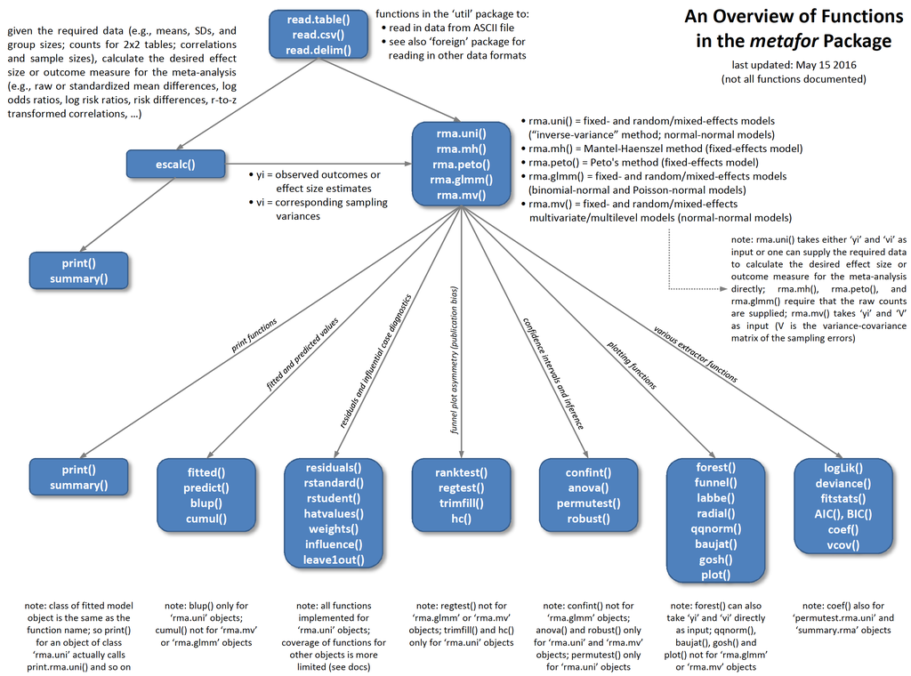

## Resumindo

- Independente do tipo de modelo que você escolher para trabalhar, é essencial que você garanta que o modelo cumpre com o que ele promete.
- Existem diversos testes disponíveis para a validação dos modelos de meta-análise, muitos dos quais são similares aos usados em outros tipos de modelos estatísticos.
- Após validar o modelo, você pode fazer o diagnóstico do mesmo, identificando a fonte de heterogeneidade nele e explorando esta heterogeneidade com moderaadores.
- O `metafor` tem muitas funcionalidades que você pode usar nesta etapa - sugiro que você explore o site do projeto, para se familiarizar com aquilo que será mais importante no seu trabalho.

## Literatura Recomendada

1. Adams et al, 1997, Ecology, Resampling tests for meta-analysis of ecological data
2. Nakagawa & Santos, 2012, Evol Ecol, Methodological issues and advances in biological meta-analysis
3. Harrison, 2011, Methods Ecol Evol, Getting started with meta-analysis
4. Rosenberg, 2013, Moment and least-squares based approaches to meta-analytic inference, In: Handbook of meta-analysis in ecology and evolution (Capítulo 9)
5. Viechtbauer, 2010, J Stat Soft, Conducting meta-analyses in R with the metafor package
6. Dúvidas gerais e dicas para o uso do `metafor`: http://www.metafor-project.org/doku.php/tips